# Understanding Naive Bayes Classifier

In this article we will explore the machine learning algorithm "Naive Bayes Classifier". The aim of this article is to give you a holistic and intuitive understanding about how this algorithm works.

Before we start our discussion on Naive Bayes Classifier, we first need to understand Classification and Bayes Classification. Classification is a task in data mining that involves assigning a class label to each instance in a dataset based on its features. The goal of classification is to build a model that accurately predicts the class labels of new instances based on their features. There are two main types of classification: binary classification and multi-class classification. Binary classification involves classifying instances into two classes, such as “spam” or “not spam”, while multi-class classification involves classifying instances into more than two classes.

Bayes Classification is a method based on Bayes's theorem. Bayes's theorem is an equation describing the relationship of conditional probabilities of statistical quantities. Bayes's theorem is stated mathematically as the following equation: $$ P(A~|~B) = \frac{P(B~|~A)P(A)}{P(B)} $$ where A and B are events and $P(B) \neq 0$.

- $P(A~|~B)$ is a conditional probability: the probability of event A occuring given that B is true. It is also called posterior probability of A given B.
- $P(B~|~A)$ is also a conditional probability: the probability of event B occuring given that A is true. It can also be interpreted as likelyhood of A given fixed B because $P(B~|~A) = L(A~|~B)$.
- P(A) and P(B) are the probabilities of observing A and B respectively without any given conditions; they are known as the prior probability and marginal probability.

Bayes classification uses Bayes's theorem to predict the occurence of any event. Bayes classifier is the statistical classifier with the Bayesian probability understanding. Bayes classifier is Bayes probability model with Bayes decision rule. One common Bayes decision rule is maximum the posterior probability. In classification we are interested in finding the probability of a label given some observed features. So we rewrite the formula of Bayes theorem: $$P(C~|~{\rm features}) = \frac{P({\rm features}~|~C)P(C)}{P({\rm features})}$$ Denote features: $x_1$, ... $x_i$, ... $x_N$ and label: $C_k$, we got the Bayes probability model: $$P(C_k | x_1, \dots x_i, \dots x_N) = \frac{P(x_1, \dots x_i, \dots x_N | C_k)P(C_k)}{p(x_1, \dots x_i, \dots x_N)}$$ The denominator doesn't dependent on $C_k$ so that: $$P(C_k | x_1, \dots x_i, \dots x_N) \propto P(C_k) \cdot P(x_1, \dots x_i, \dots x_N | C_k) $$ Then we got Bayes decision rule: $$\hat{k} = \underset{k=1,...,K}{\operatorname{argmax}} P(C_k | x_1, \dots x_i, \dots x_N) = \underset{k=1,...,K}{\operatorname{argmax}} P(C_k) \cdot P(x_1, \dots x_i, \dots x_N | C_k)$$

Naive Bayes Classifier assumes that the value of a particular feature is independent of the value of any other feature, given the class variable. In other words, in Naive Bayes we assume features: $x_1$, ... $x_i$, ... $x_N$ are independent. $$ P(x_1, \dots x_i, \dots x_N | C_k) = P(x_1 | C_k) \dots P(x_i | C_k) \dots P(x_N | C_k) = \prod_{i=1}^{N}P(x_i | C_k) $$ So that $$P(C_k | x_1, \dots x_i, \dots x_N) \propto P(C_k) \cdot \prod_{i=1}^{N}P(x_i | C_k) $$ $$\hat{k} = \underset{k=1,...,K}{\operatorname{argmax}} P(C_k) \cdot \prod_{i=1}^{N}P(x_i | C_k) $$ Specifying this generative model for each label is the main piece of training of such a Bayes Classifier. Depending on the assumption of for $P(x|C_k)$ there are 3 main types of Naive Bayes Classifiers:

- Gaussian;
- Multinomial;
- Bernoulli.

For a intuitive way to understand Naive Bayes Classification, let's take 2-D Gaussian Naive Bayes Classication with 2 classes as an example.

- We have 2 classes $C_1$ and $C_2$.
- The data is described by a Gaussian distribution with no covariance between the two dimensions.
- Let $(\mu_{1,k}, \mu_{2, k})$ be the mean of values in $(x_1, x_2)$ associated with class $C_k$.
- Let $(\sigma^2_{1,k}, \sigma^2_{2,k})$ be the variance of values in $(x_1, x_2)$ associated with class $C_k$.

$P(x_1, x_2 | C_k)$ can be computed by the normal distribution: $$P(x_1, x_2 | C_k) = \frac{1}{\sqrt{2\pi\sigma^2_{1,k}}}\,e^{ -\frac{(x_1 - \mu_{1,k})^2}{2\sigma^2_{1,k}}} \cdot \frac{1}{\sqrt{2\pi\sigma^2_{2,k}}}\,e^{ -\frac{(x_2 - \mu_{2,k})^2}{2\sigma^2_{2,k}}}$$ Then we can predict the label by:
$$\hat{k} = \underset{k=1,2}{\operatorname{argmax}} P(C_k | x_1, x_2) = \underset{k=1,2}{\operatorname{argmax}} P(C_k) \cdot P(x_1, x_2 | C_k)$$

## Gaussian Naive Bayes Classifier in Python

In this session we will see how to implement Gaussian Naive Bayes Classifier in Python. Here is a link to access my Python code on [github](https://github.com/hyman8165/GaussianNaiveBayesClassifier).

I create a class: NaiveBayesClassifier.

- There are no parameters to be initialized.
- The method fit trains the dataset and gets the parameters of likelihood associated with each class and the prior probability of the classes.
- The method predict_proba calculates the posterior probability of each class for the new observation data.
- The method predicts the label by the argmax of posterior probabilities of each class.

We will describe more detail about the fit method and predict_proba method.

Method fit has two inputs: the training data points and labels. For each feature calculates the mean and standard deviation of the points within each label. This is the $\mu_{i,k}$ and $\sigma_{i,k}$. For each label counts the number and calculated the portion of total number of data points. This is the $P(C_k)$.

Method predict_proba has one input: the testing data points. For each data point calculates the likelihood for each label and then calculates the posterior for each lable.

```python
import numpy as np
import pandas as pd
import matplotlib.pyplot as plt
```

```python
class NaiveBayesClassifier:
  def __init__(self):
    self.features = list
    self.likelihoods = {}
    self.class_priors = {}

    self.train_size = int
    self.num_feats = int
    self.outcomes = list

  def fit(self, X, y):
    self.features = list(X.columns)
    self.train_size = X.shape[0]
    self.num_feats = X.shape[1]
    self.outcomes = np.unique(y)

    for feature in self.features:
      self.likelihoods[feature] = {}
      for outcome in self.outcomes:
        mean = np.mean(X[feature][y == outcome])
        std = np.std(X[feature][y == outcome])
        self.likelihoods[feature][outcome] = {'mean': mean, 'std': std}
    for outcome in self.outcomes:
      outcome_count = sum(y == outcome)
      self.class_priors[outcome] = outcome_count / self.train_size

  def predict_proba(self, X):
    results = []
    for query in np.array(X):
      probs_outcome = []
      for ind in range(len(self.outcomes)):
        outcome = self.outcomes[ind]
        prior = self.class_priors[outcome]
        likelihood = 1
        for feature, feat_val in zip(self.features, query):
          mu = self.likelihoods[feature][outcome]['mean']
          sigma = self.likelihoods[feature][outcome]['std']
          likelihood *= np.exp(-1*(feat_val-mu)**2/(2*sigma**2))/(np.sqrt(np.pi*2)*(sigma**2))
        posterior = likelihood * prior
        probs_outcome.append(posterior)
      result = probs_outcome / np.sum(probs_outcome)
      results.append(result.tolist())
    return results

  def predict(self, X):
    probs = self.predict_proba(X)
    predicts = np.argmax(probs, axis=1)
    return self.outcomes[predicts]
```

## Test the class

For testing, we use 2-D normal distribution generator to generate two data sets. One for label one and the other for label two. Label one is integer 0 and label two is integer 1. Each data set has 200 data points. And we combined two data sets with the respect label into one data frame. Then we randomly select 80 data points from the data fram as testing set and the remaining 320 data points as the training set. After that we plot the scatter plot for the training set and testing set.

```python
mean0 = [-1.8, -9.5]
cov0 = [[1.8**2, 0], [0, 1.8**2]]
mean1 = [1.2, -1]
cov1 = [[2.2**2, 0], [0, 1.8**2]]
rng = np.random.RandomState(42)
data0 = rng.multivariate_normal(mean0, cov0, 200)
data1 = rng.multivariate_normal(mean1, cov1, 200)
dataX = np.vstack((data0, data1))
y0 = np.zeros(200)
y1 = np.ones(200)
y = np.hstack((y0, y1)).astype(int)
testIndx = rng.choice(400, size=80, replace=False, p=None)
df = pd.DataFrame(dataX, columns=['X0', 'X1'])
df['y'] = y
df_test = df.take(testIndx)
df_train = df.drop(index=testIndx)
```

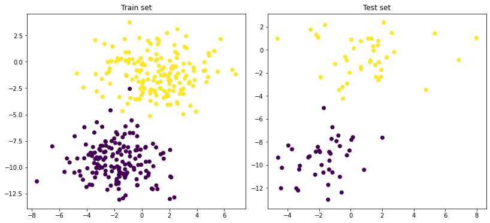

```python
fig, ax = plt.subplots(1, 2, figsize=(12,6))
fig.subplots_adjust(left=0.0625, right=0.95, wspace=0.1)

ax[0].scatter(x='X0', y='X1', c='y', data=df_train)
ax[0].title.set_text('Train set')
ax[1].scatter(x='X0', y='X1', c='y', data=df_test)
ax[1].title.set_text('Test set')
plt.show()
```

Then we create an instance of the class and fit the model with training data set. Use the fitted model we predict the label of testing data points and compare with the true testing labels. Finally we get the prediction AUC.

```python
nbc = NaiveBayesClassifier()
X_train = df_train.drop('y', axis=1)
y_train = df_train['y']
nbc.fit(X_train, y_train)
```

```python
X_test = df_test.drop('y', axis=1)
y_test = df_test['y']
probs = nbc.predict_proba(X_test)
yhat = nbc.predict(X_test)
auc = np.mean(yhat==y_test)
#print(probs)
#print(yhat)
print('auc: %.3f' % auc)
```

```
auc: 1.000
```

For the fitted model we also plot the decision boundary.

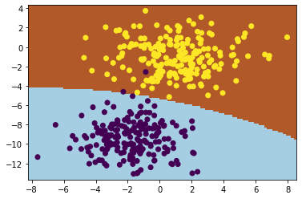

```python
x_min, x_max = df['X0'].min() - 0.5, df['X0'].max() + 0.5
y_min, y_max = df['X1'].min() - 0.5, df['X1'].max() + 0.5
xx, yy = np.meshgrid(np.linspace(x_min, x_max, 100), np.linspace(y_min, y_max, 100))
z = nbc.predict(np.c_[xx.ravel(), yy.ravel()])
z = np.array(z).reshape(xx.shape)
plt.pcolormesh(xx, yy, z, cmap=plt.cm.Paired)
plt.scatter(x='X0', y='X1', c='y', data=df)
plt.show()
```

Our model has an overall accuracy of 1.000.